# Group 35 Final Project

### Members: Maisy Christians (section 3), David Chen (section 4), Najma Abdullahi (section 5), James Park (section 3)

# Introduction

Formula One, also known as F1, is an international competition where high class open-wheel single-seater formula cars race against each other to see which automobile constructed can cross the finish line first after a given number of laps around a track. Drivers get points for the position that they finish in (higher points are given to those who finish the race course fastest). At the end of the season, the driver with the most points is crowned as the World Champion.

# Dataset tables

For our project we used the drivers, results, races, and qualifying tables.

The drivers table contains 9 variables -- driverId, driverRef, number, code, forename, surname, dob, nationality, and url. It contains basic biographical information on each driver, with each row representing a single driver.

The results table contains 18 variables -- resultId, raceId, constructorId, number, grid, position, positionText, positionOrder, points, laps, time, milliseconds, fastestLap, rank, fastestLapTime, fastestLapSpeed, statusId. Each row represents each driver's performance in every race they participated in, with one row per race.

The races table contains 18 variables -- raceId, year, round, circuitId, name, date, time, url, fp1_date, fp1_time, fp2_date, fp2_time, fp3_date, fp3_time, quali_date, quali_time, sprint_date, sprint_time. It contains information on when and where each race occurred, with each row representing one race.

The qualifying table contains 9 variables -- qualifyId, raceId, driverId, constructorId, number, position, q1, q2, and q3. It contains information on each driver's performance in the qualifying rounds for each race, with each row representing one driver's performance.

```python
import pandas as pd
import matplotlib.pyplot as plt
import numpy as np
from scipy.stats import pearsonr
```

```python
races = pd.read_csv("data_raw/races.csv")
results = pd.read_csv("data_raw/results.csv")
drivers = pd.read_csv("data_raw/drivers.csv")
qualifying = pd.read_csv("data_raw/qualifying.csv").rename(columns = {"position": "qualifying_position"})
```

# Data Cleaning

To select relevant columns, a list of column names is first defined and all columns not contained in that list are excluded form the raw dataframes before merging. Later, when creating line charts that plot the trends in national average points over time, countries with less than 30 data points (i.e. less than 30 rows) are dropped from the dataframe. This is accomplished by first counting the number of rows of each country, creating a set of countries named complete_countries that have more than 30 rows and filtering out all countries that are not contained in the list.

# Columns Selected

Two columns "raceId" and "driverId" are used for merging the data frames since they are shared by many individual dataframes. Columns "year", "nationality", and "qualifying_position" are selected as independent variables to explain change in our response variable "points". Specifically, qualifying position determines the position each driver starts in the race, and drivers who performed well in the qualifying round would be granted better qualifying positions. Point is the score offered to players after each game based on their finishing position. Points are accumulated over time and the player and the team with most points would be named champion.

```python
relevant_columns = ["raceId", "driverId", "year", "nationality", "qualifying_position", "points"]
races = races[races.columns.intersection(relevant_columns)]
results = results[results.columns.intersection(relevant_columns)]
drivers = drivers[drivers.columns.intersection(relevant_columns)]
qualifying = qualifying[qualifying.columns.intersection(relevant_columns)]
display(races.head())
display(results.head())
display(drivers.head())
display(qualifying.head())
```

|  | raceId | year |
| --- | --- | --- |
| 0 | 1 | 2009 |
| 1 | 2 | 2009 |
| 2 | 3 | 2009 |
| 3 | 4 | 2009 |
| 4 | 5 | 2009 |

|  | raceId | driverId | points |
| --- | --- | --- | --- |
| 0 | 18 | 1 | 10.0 |
| 1 | 18 | 2 | 8.0 |
| 2 | 18 | 3 | 6.0 |
| 3 | 18 | 4 | 5.0 |
| 4 | 18 | 5 | 4.0 |

|  | driverId | nationality |
| --- | --- | --- |
| 0 | 1 | British |
| 1 | 2 | German |
| 2 | 3 | German |
| 3 | 4 | Spanish |
| 4 | 5 | Finnish |

|  | raceId | driverId | qualifying_position |
| --- | --- | --- | --- |
| 0 | 18 | 1 | 1 |
| 1 | 18 | 9 | 2 |
| 2 | 18 | 5 | 3 |
| 3 | 18 | 13 | 4 |
| 4 | 18 | 2 | 5 |

# Merge Datasets

```python
races_results_merged = pd.merge(races, results,
                            on = "raceId",
                            how = "left")
mega_merged = pd.merge(races_results_merged, drivers,
                       on = "driverId",
                       how = "left")
mega_merged = pd.merge(mega_merged, qualifying,
                                        on = ["raceId", "driverId"],
                                        how = "left")
mega_merged.head()
```

|  | raceId | year | driverId | points | nationality | qualifying_position |
| --- | --- | --- | --- | --- | --- | --- |
| 0 | 1 | 2009 | 18.0 | 10.0 | British | 1.0 |
| 1 | 1 | 2009 | 22.0 | 8.0 | Brazilian | 2.0 |
| 2 | 1 | 2009 | 15.0 | 6.0 | Italian | 8.0 |
| 3 | 1 | 2009 | 10.0 | 5.0 | German | 6.0 |
| 4 | 1 | 2009 | 4.0 | 4.0 | Spanish | 12.0 |

# Unsuccessful Graphs

In the following section we display some unsuccessful attempts at visualizing data. Graph 1 looks highly untidy and disorganized because we attempted to display data for all 10 countries in one plot, which is apparently too much to fit in one plot. Also, as you can see from the second graph, the graphs display messy line plots of average points over the years. This is due to some nationalities racking up high points, but only racing for a short amount of time. The Polish and Colombian, for example, show results for only certain years because they have not raced in other years. This did not provide us with results of the top 10 nationalities with the highest average points over the years of F1, so we wanted to filter this dataset a bit more.

```python
# Obtain the 10 countries with highest average points across the years
average_ppy = (mega_merged.groupby(["nationality", "year"])
                        .agg(avg_points = ("points", "mean"))
                        .reset_index())
average_ppy
```

|  | nationality | year | avg_points |
| --- | --- | --- | --- |
| 0 | American | 1950 | 0.648649 |
| 1 | American | 1951 | 0.631579 |
| 2 | American | 1952 | 0.648649 |
| 3 | American | 1953 | 0.413793 |
| 4 | American | 1954 | 0.363636 |
| ... | ... | ... | ... |
| 1011 | Venezuelan | 2011 | 0.052632 |
| 1012 | Venezuelan | 2012 | 2.250000 |
| 1013 | Venezuelan | 2013 | 0.052632 |
| 1014 | Venezuelan | 2014 | 0.105263 |
| 1015 | Venezuelan | 2015 | 1.421053 |

1016 rows × 3 columns

```python
top_10_countries = (average_ppy.groupby("nationality")
           .agg(overall_avg_points = ("avg_points", "mean"))
           .sort_values("overall_avg_points", ascending = False)
           .reset_index()[0:10]["nationality"])
display(top_10_countries)
```

```
0    Monegasque
1       Finnish
2    Australian
3       British
4       Spanish
5       Mexican
6        Polish
7         Dutch
8     Colombian
9        German
Name: nationality, dtype: object
```

### Ugly Graph 1: Jumbled Line Chart

The following graph displays how the average score of top-10 nationalities change over time. The lines are very clustered and the graph looks very messy and disorganized.

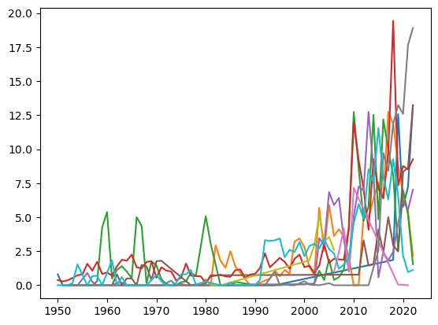

```python
for country in top_10_countries:
    subset = average_ppy.query("nationality == @country")
    plt.plot("year", "avg_points", data = subset)
```

### Ugly Graph 2: Missing Data

Subplots are used to separate out individual trends. But due to missing data, some of the plots look incomplete.

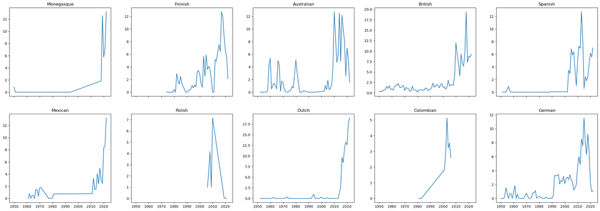

```python
fig, ax = plt.subplots(2, 5, figsize = (30, 10), sharex = True)
row = 0
col = 0

for country in top_10_countries:
    subset = average_ppy.query("nationality == @country")
    ax[row, col].plot("year", "avg_points", data = subset)
    ax[row, col].set_title(country)
    col += 1
    if (col == 5):
        row += 1
        col = 0
```

# Successful Graphs

```python
# Filter out countries with insufficient data points
row_counts = (average_ppy.groupby("nationality")
                        .agg(row_counts = ("year", "count"))
                        .reset_index())
complete_countries = row_counts.query("row_counts > 30")["nationality"]
average_ppy = average_ppy.query("nationality in @complete_countries")
```

```python
# Obtain the 10 countries with the highest average score of all time
top_10 = (average_ppy.groupby("nationality")
                               .agg(overall_avg_points = ("avg_points", "mean"))
                               .sort_values("overall_avg_points", ascending = False)
                               .reset_index()[0:10])
top_10
```

|  | nationality | overall_avg_points |
| --- | --- | --- |
| 0 | Finnish | 2.935967 |
| 1 | Australian | 2.714989 |
| 2 | British | 2.647997 |
| 3 | Spanish | 2.563092 |
| 4 | Dutch | 2.212243 |
| 5 | German | 1.960527 |
| 6 | Brazilian | 1.679421 |
| 7 | Austrian | 1.313479 |
| 8 | French | 0.991552 |
| 9 | Canadian | 0.852653 |

### Successful Plot 1: Annual Average Points of Top 10 Nationalities

After filtering out countries with less than 30 data points and reselecting the top-10 high-scoring nationalities, the line charts are able to show complete trends.

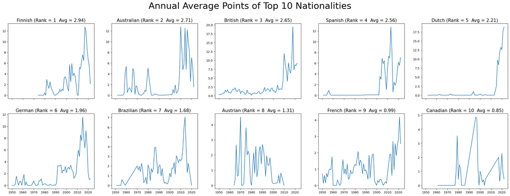

```python
fig, ax = plt.subplots(2, 5, figsize = (30, 10), sharex = True)
row = 0
col = 0
rank = 1

for country in top_10["nationality"]:
    subset = average_ppy.query("nationality == @country")
    overall_avg = round(top_10.loc[rank - 1, "overall_avg_points"], 2)
    ax[row, col].plot("year", "avg_points", data = subset)
    ax[row, col].set_title(country + f" (Rank = {rank}  Avg = {overall_avg})", size = 15)
    col += 1
    rank += 1
    if (col == 5):
        row += 1
        col = 0

fig.suptitle("Annual Average Points of Top 10 Nationalities", size = 30)
```

### Successful Plot 2: Nationalities with Top 10 Average Points Across All Years

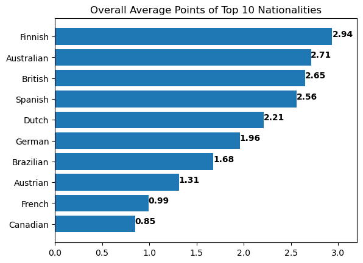

```python
plt.barh("nationality", "overall_avg_points", data = top_10)
plt.xlim(0, 3.2)
plt.title("Overall Average Points of Top 10 Nationalities")
plt.gca().invert_yaxis()

for i in range(0, 10):
    overall_avg = round(top_10.loc[i, "overall_avg_points"], 2)
    plt.text(overall_avg, i, str(overall_avg), fontweight = "bold")
```

### Compute National Average Points and Qualifying Positions

```python
average_points_positions = (mega_merged.groupby("nationality")
                                        .agg(avg_points = ("points", "mean"),
                                             avg_positions = ("qualifying_position", "mean")))
average_points_positions.dropna(inplace = True)
average_points_positions.head()
```

| nationality | avg_points | avg_positions |
| --- | --- | --- |
| American | 0.780297 | 17.515152 |
| Argentine | 1.873780 | 20.142857 |
| Australian | 3.445189 | 8.959821 |
| Austrian | 1.435507 | 11.699346 |
| Belgian | 0.656514 | 18.531646 |

### Successful Plot 3: Correlation between Qualifying Position and Point

This graph shows that there is correlation between the qualifying positions and the points that each nationality received on average. This means that the nationalities were able to have a better ranking, and one cause of them having the points that they do is because of the qualifying position that they had. However, We also know that the qualifying positions are due to how good the drivers do in the qualifying race. Therefore, we can say that if the drivers do well in the qualifying race then they are more likely to also do well in the race.

[figure not shown]

```python
x_data = average_points_positions["avg_points"]
y_data = average_points_positions["avg_positions"]


plt.scatter(x_data, y_data)
a, b = np.polyfit(x_data, y_data, 1)
corr = round(pearsonr(x_data, y_data)[0], 3)
pval = round(pearsonr(x_data, y_data)[1], 3)
plt.plot(x_data, x_data * a + b, color = "red")
plt.xlabel("National Average Qualifying Position")
plt.ylabel("National Average Point")
plt.title("Correlation between Qualifying Position and Point")
plt.legend([f"Corr = {corr} \n P-val = {pval}"])
```

# Discussion

After filtering the dataset to keep countries that have raced for more than 30 years, the team found different results. This time, the Finnish ranked first with 2.94 average points over the years and there has been some major changes to the ranking of other countries as well. Overall, our findings support that sufficient data points is necessary to obtain an accurate picture of countries' performance as the occasional success of some countries might overshadow the high performance of countries that consistently do well.